# Assignment 2

This assignment consists of two parts provided below. Complete the code assignments using the skeleton code (Listing 1) provided at the bottom of this page. Answer the indented question to each numbered task in a comment below your code using `#`. Note that the auto-corrector only tests the results of your code, not your text answer. Answers to the text questions will be published after the deadline for self-assessment.

Make sure your code adheres to the following guidelines:

- Your code does **not** overwrite or modify any of the variables in the skeleton code after completing each task. It will cause the auto-corrector to fail. This includes modifications of the datasets that are not explicitly asked for.
- Your code passes the [auto-corrector](https://statistics-umu.shinyapps.io/data-analytics-with-r/). If your code doesn’t pass at the deadline, submit it anyway.

Good luck!

### Part 1

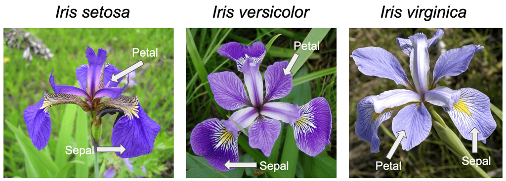

Figure 1: Three different spieces of Iris flower

In this part you will explore the iris flower dataset that is built into R. You can use the command `?iris` in R if you want to get some information about the dataset.

- Copy the skeleton code (Listing 1).
- Look at Figure 1 and relate the variables in the dataset to the figure. What is petal and sepal? What does width and length refer to? How are the measurements done? Try Googling for images if Figure 1 is not enough.
1. Compute the correlations between all numeric variables in the dataset. Save the result in a variable called `correlations`.
   - Are the correlations positive or negative? Does this make sense to you?
2. Use ggplot to create a scatterplot with the sepal width on the x axis against the sepal length on the y axis. Save the resulting plot in a variable called `plot1`.
   - How does the plotted points match the correlations we computed before?
3. Fit a linear regression model predicting the sepal length using sepal width. Save the model in a variable called `model1`.
   - Does the estimated coefficient for sepal width match what have seen in tasks 1 and 2?
4. Compute the correlations between all numeric variables in the dataset *using only the setosas*. Save the result in a variable called `correlations_setosa`.
   - Are these correlations positive or negative? How are they different from the overall correlations? Does this make sense?
5. Use ggplot to create a scatterplot with the sepal width on the x axis against the sepal length on the y axis. Color the points by flower species. Save the resulting plot in a variable called `plot2`
   - Does this match the correlations we computed for setosa flowers?
6. Fit a linear regression model predicting the sepal length using sepal width and the flower species. Save the model is a variable called `model2`.
   - Does the estimated coefficient for Sepal.Width make sense? What happened when we added species to our model? How does it change the interpretation?
7. Predict the sepal length of a setosa with a sepal width of 3.6 cm using your second model. Save the resulting prediction in a variable called `prediction`.
   - Does the prediction appear reasonable?

### Part 2

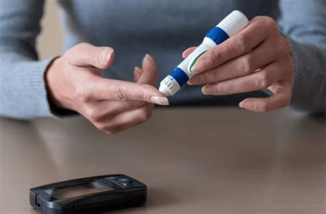

Figure 2: Glucose Tolerance Test

In this part, we will look for important factors for predicting the onset of diabetes in Pima Indian women. *Important:* the dataset should be downloaded from Canvas and *not* from mlbench as in the lecture notes.

- Download the Diabetes data from Canvas under Modules/Datasets/Diabetes data and store it in your working directory without renaming the file. This is important as the auto-corrector expects the code to search for the dataset in the working directory. Tip: If you don’t know which is your current working directory, run `getwd()`. If you use `setwd()` in your code, please remove or comment this line before submitting to the autocorrector/Canvas.
- Load the data and familiarize yourself with the dataset by performing EDA and reading about the variables on Canvas.
  - What predictors do you think will be relevant for the analysis? How is diabetes diagnosed and when is it measured with respect to the other variables in the dataset?
8. Recode the variable `Outcome` as a factor (but do not recode any other variables).
- Explore the data to find a set of “good” predictors for diabetes using descriptive statistics, plots, significance, and AIC. This should be done *before* imputation (next task).
9. Impute missing values **in all variables** using mean imputation and store the imputed data in a variable called `imputed_data`. Make sure you do your data exploration before imputation, otherwise you will get biased results.
10. Find your final logistic regression model where all predictors have statistically significant relationships with the outcome at a 5% significance level. Save the final model in a variable called `logistic_model`.
11. Compute the accuracy of your model. If the accuracy is at least 76.5% when predicting the outcome using a classification threshold of 50%, save it in a numeric variable called `accuracy`. Otherwise go back to task 10. and find a new set of predictors.
    - Reflect on why it may not always be a good idea to use the same data for fitting the regression model and evaluating its prediction accuracy.

*Make sure your R script runs from top to bottom after restarting R.*

Listing 1: Skeleton Code

```r
# 1. Correlations
correlations <- ...
# Text answer...

# 2. Plot Sepal.Width against Sepal.Length
plot1 <- ...
# Text answer...

# 3. Fit a linear model using Sepal.Width as predictor and Sepal.Length as response
model1 <- ...
# Text answer...

# 4. Setosa correlations
correlations_setosa <- ...
# Text answer...

# 5. Plot Sepal.Width against Sepal.Length, color by species
plot2 <- ...
# Text answer...

# 6. Fit second model using species and Sepal.Width as predictors and Sepal.Length as response
model2 <- ...
# Text answer...

# 7. Predict the sepal length of a setosa with a sepal width of 3.6 cm
prediction <- ...
# Text answer...

# Download the dataset from Canvas an place in current directory
getwd()

# Load the data
diabetes_data <- read_csv("a2_diabetes.csv") # Don't change this line!

# Reflect over important variables

# 8. Recode Outcome as a factor
diabetes_data <- ...

# 9. Impute missing values
imputed_data <- ...

# 10. Find a logistic regression model with significant predictors
logistic_model <- ...

# 11. Compute accuracy of your model
accuracy <- ...
# Text answer...
```